# How AI is changing business education and the future of work

What changes for our students, and for us

Kerry Back, Rice University

at SMU Cox School of Business

October 30, 2026

## VisiCalc on Apple II, 1979

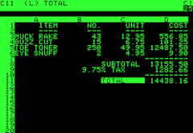

## The future of work

> Artificial intelligence is going to replace literally half of all white-collar workers in the U.S.

> If you work in finance doing spreadsheets … those jobs are definitely going to be changed and eliminated with at least this first inning of AI.

Ford CEO Jim Farley. Left: Aspen Ideas Festival, June 2025. Right: Accelerate the Essential Economy event, Detroit, reported by Fortune, July 2025.

## JP Morgan

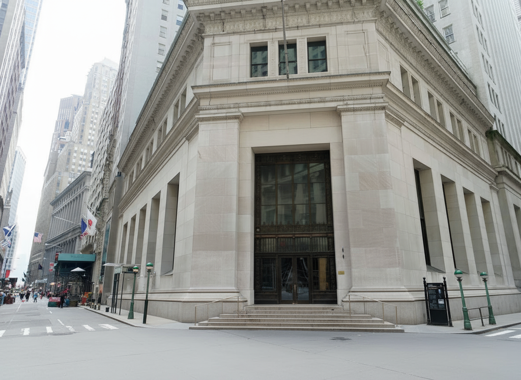

> You’ll still have people at the top who are managing and have relationships with clients, but many, many of the processes underneath are now being done by AI systems.

JP Morgan Chief Analytics Officer Derek Waldron, [CNBC interview, September 30, 2025](https://www.cnbc.com/2025/09/30/jpmorgan-chase-fully-ai-connected-megabank.html)

## AI expertise at Cox

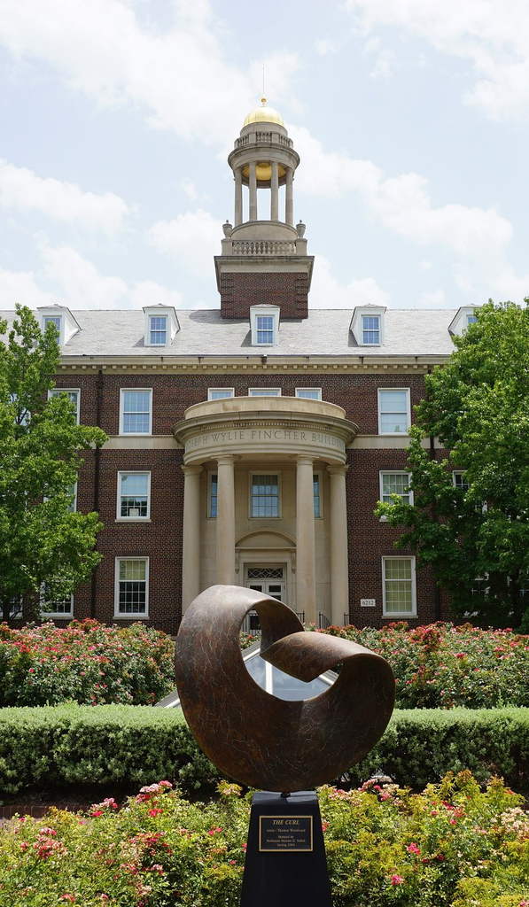

Photo: Michael Barera, CC BY-SA 4.0

> AI expertise is no longer optional. In addition to AI centric type courses, whether it’s our M.S. degree program or it’s an AI marketing course, we’ve integrated AI platforms in all of our presentation skills courses, which every undergraduate and graduate student has to take.

William Dillon, Senior Associate Dean, [Dallas Business Journal](https://www.bizjournals.com/dallas/news/2025/09/04/ai-masters-business-smu-cox-expertise.html) podcast, September 2025, quoted on [AI @ Cox](https://www.smu.edu/cox/ai-at-cox)

## Pillars of business-school education

[figure not shown]

# AI expertise

## Anatomy of an agent

[figure not shown]

## Timeline of agent tools

Feb 2025

Claude Code

research preview

May 2025

Remote MCP connectors

in Claude; Claude Code GA

Jul 2025

Subagents

in Claude Code

Sep 2025

Claude Agent SDK

renamed from Claude Code SDK

Oct 2025

Skills and plugins

Claude Code on the web

Jan 2026

Cowork

Claude Code for non‑coders

## This is not your father’s AI

October 2025

“They just don’t work. They don’t have enough intelligence … I feel like the industry is making too big of a jump and is trying to pretend like this is amazing, and it’s not. It’s slop.”

January 2026

“I really am mostly programming in English now, a bit sheepishly telling the LLM what code to write… in words.”

February–March 2026

“It is hard to communicate how much programming has changed due to AI in the last 2 months … Coding agents basically didn’t work before December … I don’t think I’ve typed like a line of code probably since December.”

Andrej Karpathy: OpenAI co-founder, former Tesla AI chief, now at Anthropic

## New student deliverables

- Software apps
- Skills
- Custom agents

## Vibe coding

- Students can submit software in addition to spreadsheets.
- Artifacts: single-page HTML apps. Claude can create and deploy.
- More complex software (with backend server). They can run locally or deploy in the cloud or company servers.
- Example: [Tangency portfolio](https://tangency.kerryback.com)

## Agent skills

- A skill is a text file of custom instructions for a particular task.
- It can be accompanied by code, including software programs that the agent launches and interacts with.
- Use Claude, ChatGPT, or Gemini with custom instructions and software tools in lieu of a custom agent.
- Interaction is via the usual prompt window.

## Plugins

- Mechanism for distributing skills.
- In Claude desktop: Customize → Plugins → Add marketplace.
- Anthropic’s plugin library: github.com/anthropics/claude-plugins-official
- kerryback-public plugin library: github.com/kerryback/kerryback-public

## MCP servers (connectors)

- An MCP server sits between an agent and an external service or database.
- It uses the external service’s API and creates tools (functions) from them, which it describes in text form to a connected agent.
- The agent acquires the tools exposed by the server, so it can use the external service.
- Examples: Gmail, Microsoft 365, Slack, Workday, Salesforce, …

## Example exercises

1. Build a dashboard (app) that uses the EIA’s API and shows trends in energy prices and volumes.
2. Connect Claude (or Codex, …) to an EIA MCP server (e.g., eia.kerryback.com/mcp). Create a skill that produces particular plots of energy prices and volumes when invoked.
3. Install the finance-data plugin from the kerryback-public library. Get 60 months of WMT returns using Yahoo Finance data and get MKT-RF and RF from French’s data library for the same 60 months. Run the CAPM regression to estimate WMT’s beta.

## Custom agents

- Custom chatbots with custom tools making API calls.
- Easy to build with agent software development kits (SDKs): code that implements Claude Code or Codex or …
- Students can build them around class concepts.
- Example of an agent built with a two-line prompt: eia-agent.kerryback.com

## Prompting

Say what you want

Not what to do.

Ask for the best way (plan) first

Then tell it to proceed.

Ask AI to interrogate you

Let it decide what it needs to know.

Beware of tunnel vision

Ask: is there a better path?

Steelman

“What is the strongest argument against this?”

Numbers need code

“Compute this in Python.”

## Teaching students to check AI work

Have AI explain its work

“Explain what you did step by step. Did you make any decisions that we have not discussed?”

Use another AI agent to check the work

A fresh conversation or a subagent (a second agent that the first agent starts), given your goals and the first agent’s explanation.

Have AI build a spreadsheet when possible

Then check the formulas. Every number traces back to its inputs.

Run the same code on small examples

Ask AI to run its code on a few rows you can check by hand.

# Strong fundamentals

## Flipping the classroom

- We have to expect out-of-class assignments will be done by AI.
- Assessing in class by cold-calling remains viable.
- This suggests flipping the classroom: providing lectures beforehand and spending class time interacting (case-style teaching).

## AI tutors

- AI is a great teaching tool.
- We can add value by controlling what it emphasizes and how it explains things.
- Customized AI tutors will replace textbooks.
- Examples: tutors.kerryback.com

## A skill for creating AI tutors

- Building things with AI is great, but building things to build things is even better.
- Instead of creating DCFs, students should create skills or custom agents for creating DCFs.
- The next slide is an image from a skill for creating AI tutors:

## From the tutor skill

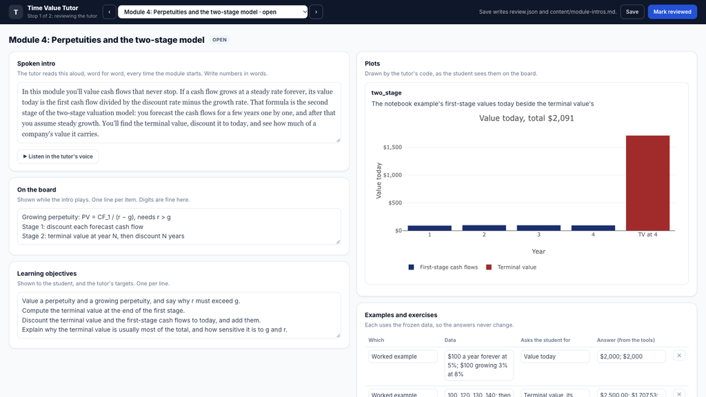

## AI can facilitate teaching fundamentals

- We can spend less time on mechanics (e.g., Excel keystrokes) and more on concepts, keeping enough technique to check AI’s work.
- Learning can be more hands-on. Students can prompt AI through the solution of real examples.
- We can be more ambitious. With concepts accelerated and better tools, we can go deeper.
- We can heighten interest and relevance by requiring AI or AI-built deliverables: apps, skills, and agents.

# Critical thinking

## Bank CEOs about AI

> I need human judgment, I need human decision making, I need human accountability at the core.

HSBC CEO Georges Elhedery, [Bloomberg TV interview](https://www.bloomberg.com/news/videos/2026-06-08/hsbc-ceo-says-bank-still-needs-human-judgment-in-ai-era-video), June 8, 2026

> The goal is to remove the repetitive, administrative work so our people can focus on what they do best—we’re not replacing critical thinking and judgment, we’re removing the tedious, time-consuming work that gets in the way of it.

Customers Bank CEO Sam Sidhu, statement to [Fortune](https://fortune.com/2026/04/28/ceo-of-customers-bank-sam-sidhu-ai-clone-lead-earnings-call-mark-zuckerberg-building-digital-twin/), April 28, 2026

## Why AI is weaker on judgment calls

> The gulf between LLM performance on verifiable tasks vs. unverifiable tasks that require judgment is larger than most people realize. Verifiable tasks, like coding or solving math problems, have a right answer that can be checked automatically. Judgment tasks don’t have unambiguous, ground-truth, correct answers. But they do have better and worse answers.

> We have much better techniques for training AI systems to do well on verifiable tasks. As a result, progress on performing such tasks has been much faster than for judgment tasks.

Andrew Ng, co-founder and former head of Google Brain, co-founder of Coursera and DeepLearning.AI · The Batch, October 16, 2026

## An example of poor reasoning

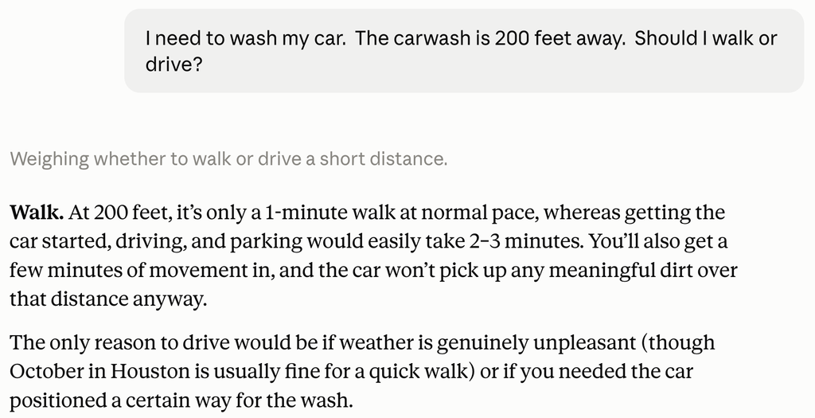

Claude Haiku 4.5, an older version of Anthropic’s smallest model, October 17, 2026

## Newer models are better

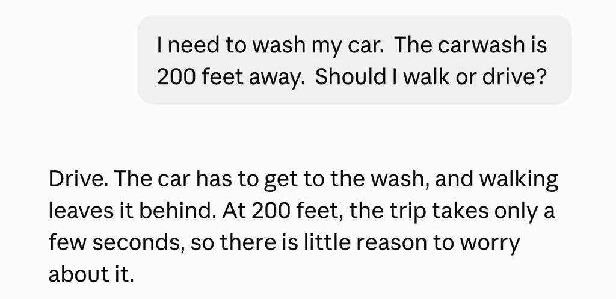

Claude Haiku 5.5, October 17, 2026

## Anthropic experiment

1. 50 causal-inference practitioners analyze observational data on a fictional farm-advisory program, working with Claude Code (Opus 4.8), and recommend roll out or discontinue.
2. Four analytical decisions (productivity measure, identification strategy, estimand, weighting) and the final recommendation each have two defensible options.
3. For each decision, a coin flip sets which option the agent leans toward. A hidden system prompt tells the agent to hold that lean strongly and voice it.
4. The agent makes the best honest case for its lean. Participants can choose any option.

Herdağdelen, Joren and Tamkin (2026), “Who’s Aligned to Whom? How AI Agents Shape Experts’ Research Judgment Calls,” Anthropic.

## Results

86% of analytical decisions went with the agent’s lean (50% by chance)

77% repeated the agent’s talking points

15% mentioned the agent

- The four analytical leans alone predicted 82% of final recommendations, against a 61% baseline (exploratory).
- The agent’s lean on the final recommendation moved it 17% of the way from discontinue to roll out (one-sided p = 0.07).
- Participants who took a side and then heard the agent lean the other way switched 60% of the time.
- More than half rated the recommendation as more their own than the agent’s.

Herdağdelen, Joren and Tamkin (2026), “Who’s Aligned to Whom? How AI Agents Shape Experts’ Research Judgment Calls,” Anthropic.

## What doesn’t affect reliance on AI

- An AI writing assistant (GPT-3.5 and GPT-4) offered autocomplete suggestions with a set position on societal issues.
- 2,582 participants. Their attitudes shifted toward the assistant’s position.
- Warning participants about the bias, before or after writing, did not reduce the shift.

Williams-Ceci et al. (2026), “Biased AI Writing Assistants Shift Users’ Attitudes on Societal Issues,” Science Advances.

## What does affect reliance on AI

| What the LLM did | Study | Finding |
| --- | --- | --- |
| Stated uncertainty in the first person (“I’m not sure, but…”) | Kim et al. (2024), 404 participants, medical questions | Agreed with the LLM less and answered more accurately |
| Cited sources | Kim et al. (2025), 308 participants | Relied less on incorrect answers |
| Explained its answer | Kim et al. (2025), 308 participants | Relied more on both correct and incorrect answers |
| Added a disclaimer, highlighted uncertain words, or implied the answer without stating it | Bo, Wan and Anderson (2025), 400 participants | Relied less on wrong answers, but also less on right ones |

All three studies use questions with a correct answer.

## A possible CLAUDE.md section

```
## Judgment calls

A judgment call is a decision with more than one defensible answer:
a method, an assumption, an interpretation, or a recommendation.

1. When you reach a judgment call, run each option and check
   whether the result changes.
2. If the result changes, stop and name the judgment call.
   Make the best case for each option, with equal effort.
   Refuse to do more than that. Do not recommend a choice.
3. If the result does not change, list the judgment call
   at the end of your answer.
```

## AI can facilitate teaching critical thinking

- People must make the decisions, but AI should be used to provide the information needed to make them.
- We can model this in the classroom. Use AI tools to gather information, do standard calculations, and assemble the information in a useful format. Then focus on making judgments where there is ambiguity.
- Example (automate the repetitive stuff): kerryback.com/aapl.html

# An opportunity: AI is just getting started

## Adoption is broad but shallow

Census Bureau, 2026

- About 1 in 5 US firms use AI; 30% of firms with 250+ employees.
- Most use it in three or fewer business functions.
- 2% report AI-related job cuts.

Real-Time Population Survey, 2026

- 39% of workers used generative AI for work in the past week.
- 6.3% of work hours were assisted by AI.
- 2.2% of work hours were saved.

Yale Budget Lab, 2026

- No connection between AI use and changes in employment or unemployment.
- No clear sign yet of labor market effects.

Sources: [Census Bureau CES Working Paper 26-25](https://www2.census.gov/library/working-papers/2026/adrm/ces/CES-WP-26-25.pdf) and [Minneapolis Fed](https://www.minneapolisfed.org/article/2026/ai-adoption-in-business-grows-steadily-but-unevenly) · Bick, Blandin, and Deming, via [FRED Blog](https://fred.stlouisfed.org/blog/2026/08/does-generative-ai-save-time-at-work/) · [Yale Budget Lab](https://budgetlab.yale.edu/research/tracking-impact-ai-labor-market)

## Security is one reason: the Copilot case

CVE-2025-32711 — June 2025

1. The attacker sends the victim an ordinary-looking email whose instructions read as if meant for the recipient.
2. The victim asks Copilot a work question. Copilot retrieves that email and reads the instructions.
3. Following them, Copilot embeds confidential data in a URL in its response.

## Cost is another

> My token cost … is shooting through the roof. … Clients are ready to scale AI, but then they hit this unexpected cost wall.

Lan Guan, Chief AI and Data Officer, Accenture, [Fortune](https://fortune.com/2026/07/29/cfo-hitting-cost-wall-ai-tokens-accenture/), July 29, 2026

- Uber used up its 2026 AI budget by April, four months after rolling out Claude Code to engineers.
- Microsoft’s Experiences + Devices group is moving engineers off Claude Code to GitHub Copilot CLI. Microsoft calls it “toolchain unification.” Press reports point to cost.

[Forbes](https://www.forbes.com/sites/janakirammsv/2026/05/17/uber-burns-its-2026-ai-budget-in-four-months-on-claude-code/), May 17, 2026, citing The Information · [The Next Web](https://thenextweb.com/news/microsoft-claude-code-retreat-ai-cost), May 25, 2026, citing Windows Central and The Verge

## But cost is falling

- We no longer need the best models for most work. Cheaper models are adequate — e.g., replace Fable with Sonnet.
- Open weight models are very competitive and cheaper. From Meta, Mistral, DeepSeek, Alibaba, Moonshot, Z.ai, Xiaomi, …
- Some are hosted on Amazon Bedrock, Google Vertex AI, Microsoft Azure, … DPAs and BAAs are available.
- A 1-trillion-parameter model can run on four linked Mac Studios with 512GB each ($90,000 total).

## B-school SWOT analysis

Strengths

- Community: classroom, cohort, network.
- Expert faculty.

Weaknesses

Some of what we have historically taught can now be done very cheaply and quickly by AI.

Opportunities

We can produce AI leaders who are strong in fundamentals and critical thinking.

Threats

Over-reliance on AI by students weakens learning and judgment.

## Footnote: Try Academic Studio

Academic Studio (my project) is a fork of VS Code designed for non-coding Claude Code users.